# Lab9

Hoa Hoang

Thursday, March 26, 2020

## Task1

```r
getwd()
```

```
## [1] "C:/Users/hoaho/OneDrive/Desktop/Classworks/Math4753/Lab9"
```

## Task2

```r
myboot<-function(iter=10000,x,fun="mean",alpha=0.05,...){

#Notice where the ... is repeated in the code
n=length(x)   #sample size

#Now sample with replacement
y=sample(x,n*iter,replace=TRUE) #A

# Make a matrix with all the resampled values
rs.mat=matrix(y,nr=n,nc=iter,byrow=TRUE)
xstat=apply(rs.mat,2,fun)
# xstat is a vector and will have iter values in it
ci=quantile(xstat,c(alpha/2,1-alpha/2)) #B
# Nice way to form a confidence interval
# A histogram follows
# The object para will contain the parameters used to make the histogram
para=hist(xstat,freq=FALSE,las=1,main="Histogram of Bootstrap sample statistics",...)

#mat will be a matrix that contains the data, this is done so that I can use apply()
mat=matrix(x,nr=length(x),nc=1,byrow=TRUE)

#pte is the point estimate
#This uses whatever fun is
pte=apply(mat,2,fun)
abline(v=pte,lwd=3,col="Black")# Vertical line
segments(ci[1],0,ci[2],0,lwd=4)      #Make the segment for the ci
text(ci[1],0,paste("(",round(ci[1],2),sep=""),col="Red",cex=3)
text(ci[2],0,paste(round(ci[2],2),")",sep=""),col="Red",cex=3)

# plot the point estimate 1/2 way up the density
text(pte,max(para$density)/2,round(pte,2),cex=3)

return(list(ci=ci,fun=fun,x=x))# Some output to use if necessary
}
```

### Code Explain of Line A and B

Line A is sampling with replacement by using the x vector with the size of n*iter  
Line B is sampling quantiles corresponding to the given probabilities. It use the xstat vector and c(alpha/2,1-alpha/2) probability

### As used in the myboot() function, each datum in x will be selected with equal probability. Why is this necessary?

It is to ensure the resampling will retain as much information as possible

### Explain unique()

```r
set.seed(35) # This will give everyone the same sample
sam=round(rnorm(20,mean=10,sd=4),2)
unique(sample(sam,20,replace=TRUE) ) # repeat this line 5Xs
```

```
##  [1] 12.05 23.35 11.40 14.26  8.43 13.46  2.37  8.62 17.35 11.64 14.76  9.82
```

```r
#Explain what you see.
unique(sample(sam,20,replace=FALSE) ) # repeat this line 5Xs
```

```
##  [1]  8.43 14.26  7.75  2.89 12.05  8.62  9.82 17.35 10.53 23.35  6.93 11.40
## [13]  2.37  8.00 11.78 16.69  9.86 11.64 14.76 13.46
```

```r
#Explain what you see.
```

What unique does is remove duplicate. The first sample() will have less value as some of them are removed. The second sampling change nothing as we don’t do replacement

### What happens? Why? (with the folling code)

```r
# sample(sam,21,replace=FALSE)
```

This sample() will not run since in sam, we only have 20 values. We want 21 with no replacement. Short on 1 value

## Task 3

```r
myboot2<-function(iter=10000,x,fun="mean",alpha=0.05,cx=1.5,...){  #Notice where the ... is repeated in the code
n=length(x)   #sample size

y=sample(x,n*iter,replace=TRUE)
rs.mat=matrix(y,nr=n,nc=iter,byrow=TRUE)
xstat=apply(rs.mat,2,fun) # xstat is a vector and will have iter values in it
ci=quantile(xstat,c(alpha/2,1-alpha/2))# Nice way to form a confidence interval
# A histogram follows
# The object para will contain the parameters used to make the histogram
para=hist(xstat,freq=FALSE,las=1,
main=paste("Histogram of Bootstrap sample statistics","\n","alpha=",alpha," iter=",iter,sep=""),
...)

#mat will be a matrix that contains the data, this is done so that I can use apply()
mat=matrix(x,nr=length(x),nc=1,byrow=TRUE)

#pte is the point estimate
#This uses whatever fun is
pte=apply(mat,2,fun)
abline(v=pte,lwd=3,col="Black")# Vertical line
segments(ci[1],0,ci[2],0,lwd=4)      #Make the segment for the ci
text(ci[1],0,paste("(",round(ci[1],2),sep=""),col="Red",cex=cx)
text(ci[2],0,paste(round(ci[2],2),")",sep=""),col="Red",cex=cx)

# plot the point estimate 1/2 way up the density
text(pte,max(para$density)/2,round(pte,2),cex=cx)

invisible(list(ci=ci,fun=fun,x=x))# Some output to use if necessary
}
```

### 4 myboot2() with alpha = 0.05

```r
a=0.05
set.seed(39)
sam1=rnorm(25,mean=25,sd=10)
sam1.mean=myboot2(x=sam1,alpha=a,xlab="Mean")
```

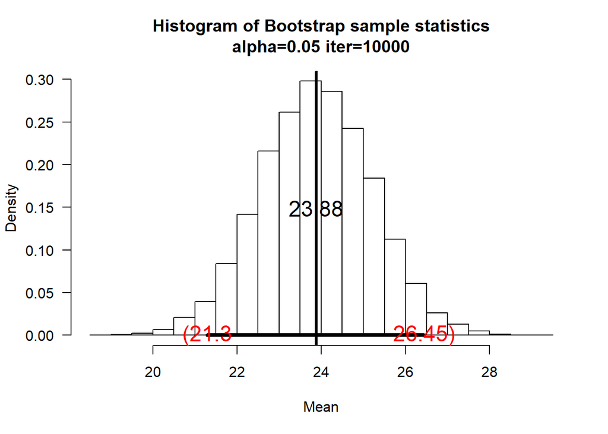

```r
set.seed(30)
sam2=rchisq(20,df=3)
sam2.mean=myboot2(x=sam2,alpha=a,xlab="Mean")
```

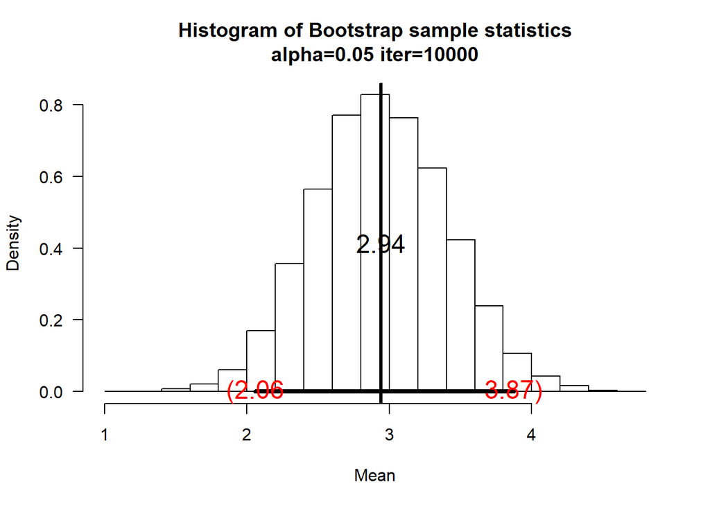

```r
set.seed(40)
sam3=rgamma(30,shape=2,scale=3)
sam3.mean=myboot2(x=sam3,alpha=a,xlab="Mean")
```

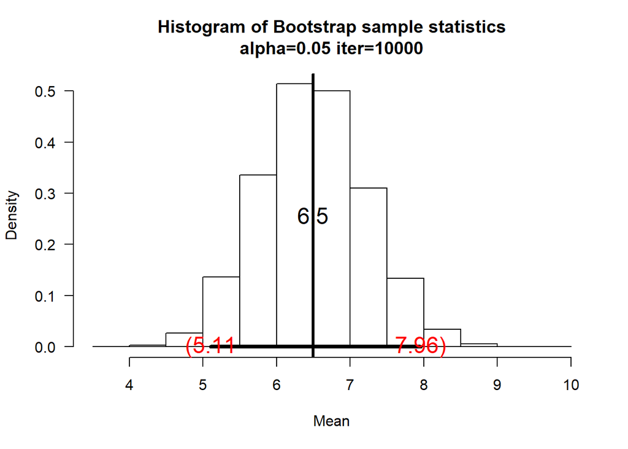

```r
set.seed(10)
sam4=rbeta(20,shape1=3,shape2=4)
sam4.mean=myboot2(x=sam4,alpha=a,xlab="Mean")
```

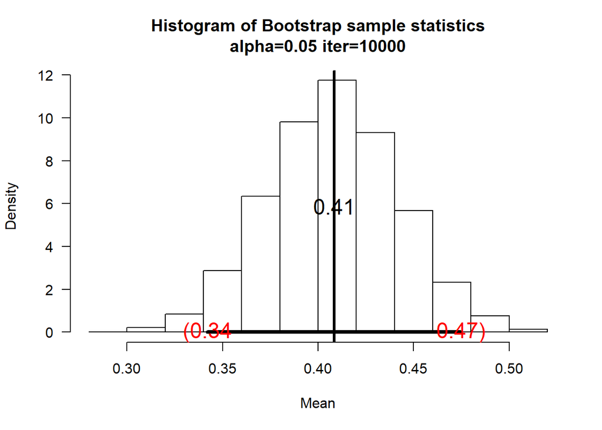

### In each of the above cases how close is the point estimate to the population value?

All of them are very close to the population mean.  
Mean of rnorm is 25  
Mean of rchisq is 3  
Mean of rgamma is 6  
Mean of rbeta is 3/(7) = 0.42

### In each of the above cases does the interval contain the population value?

Yes, all of the means are in the intervals

### 4 myboot2() with alpha = 0.2

```r
a=0.2
set.seed(39)
sam1=rnorm(25,mean=25,sd=10)
sam1.mean=myboot2(x=sam1,alpha=a,xlab="Mean")
```

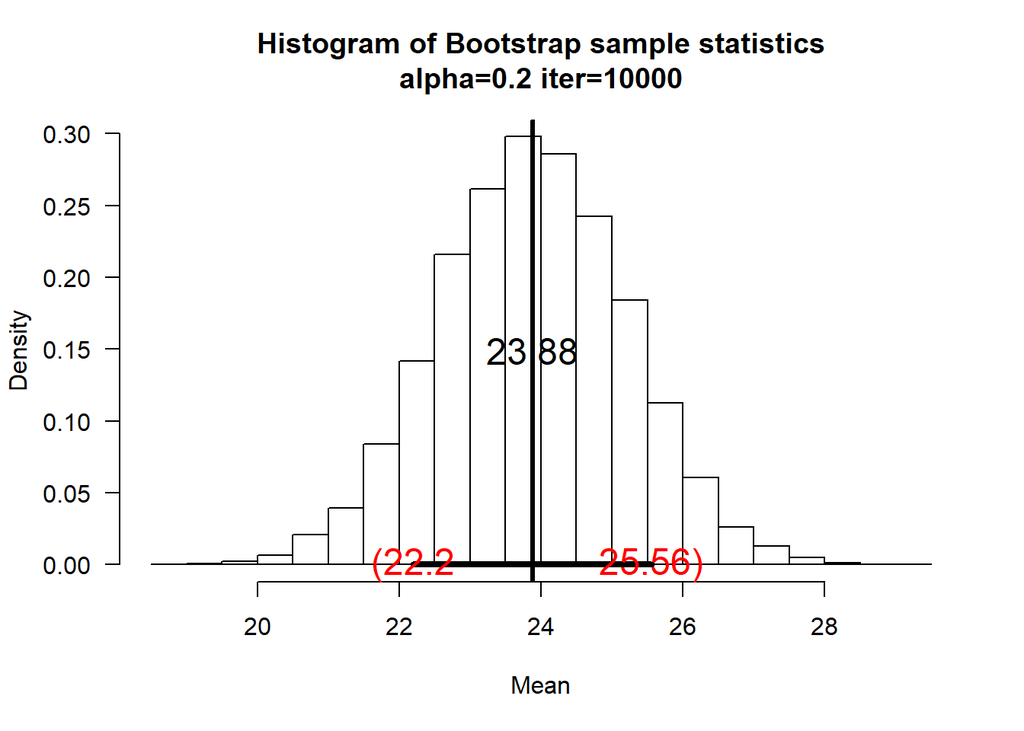

```r
set.seed(30)
sam2=rchisq(20,df=3)
sam2.mean=myboot2(x=sam2,alpha=a,xlab="Mean")
```

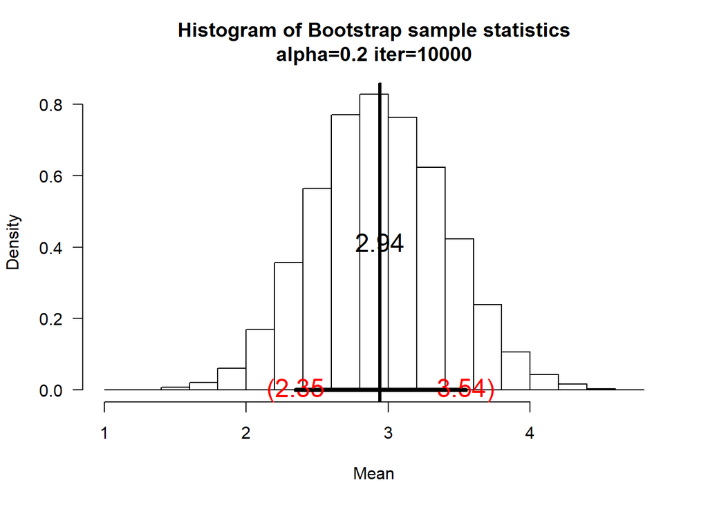

```r
set.seed(40)
sam3=rgamma(30,shape=2,scale=3)
sam3.mean=myboot2(x=sam3,alpha=a,xlab="Mean")
```

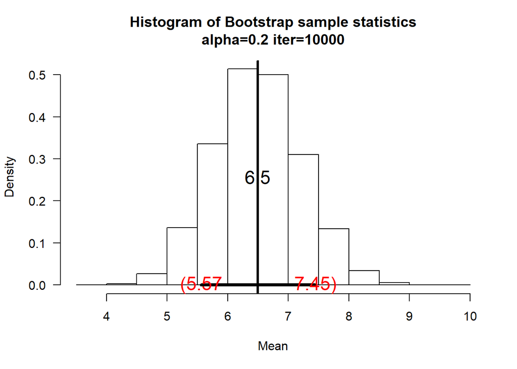

```r
set.seed(10)
sam4=rbeta(20,shape1=3,shape2=4)
sam4.mean=myboot2(x=sam4,alpha=a,xlab="Mean")
```

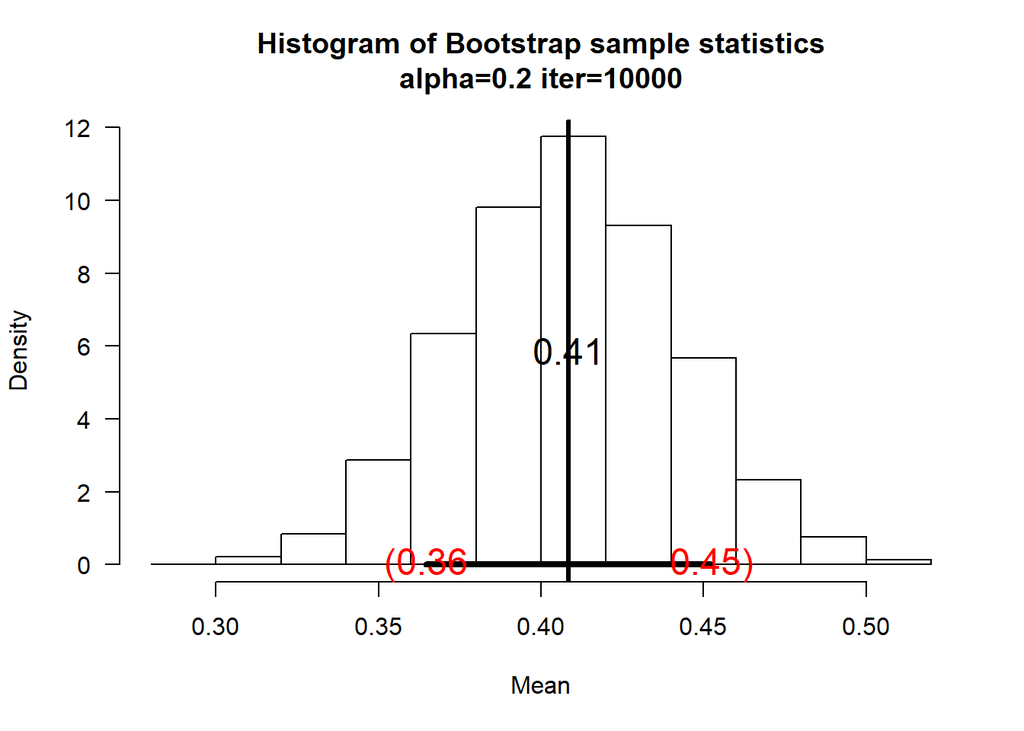

## Task 4

### Adjust myboot2()

```r
newmyboot<-function(iter=10000,x,fun="mean",alpha=0.05,...){

#Notice where the ... is repeated in the code
n=length(x)   #sample size

#Now sample with replacement
y=sample(x,n*iter,replace=TRUE) #A

# Make a matrix with all the resampled values
rs.mat=matrix(y,nr=n,nc=iter,byrow=TRUE)
xstat=apply(rs.mat,2,fun)
# xstat is a vector and will have iter values in it
ci=quantile(xstat,c(alpha/2,1-alpha/2)) #B
# Nice way to form a confidence interval
# A histogram follows
# The object para will contain the parameters used to make the histogram
para=hist(xstat,freq=FALSE,las=1,main="Histogram of Bootstrap sample statistics",...)

#mat will be a matrix that contains the data, this is done so that I can use apply()
mat=matrix(x,nr=length(x),nc=1,byrow=TRUE)

#pte is the point estimate
#This uses whatever fun is
pte=apply(mat,2,fun)
abline(v=pte,lwd=3,col="Black")# Vertical line
segments(ci[1],0,ci[2],0,lwd=4)      #Make the segment for the ci
text(ci[1],0,paste("(",round(ci[1],2),sep=""),col="Red",cex=3)
text(ci[2],0,paste(round(ci[2],2),")",sep=""),col="Red",cex=3)

# plot the point estimate 1/2 way up the density
text(pte,max(para$density)/2,round(pte,2),cex=3)

return(list(xstat=xstat,ci=ci,fun=fun,x=x))# Some output to use if necessary
}
```

### Using the adjusted myboot()

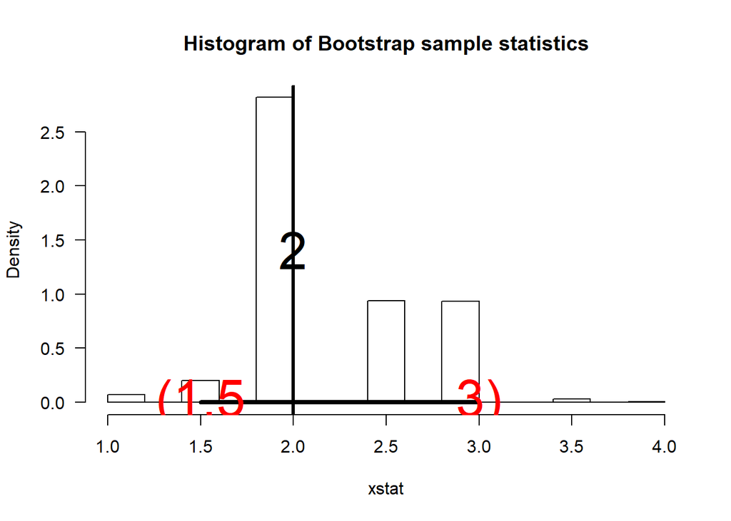

[output not shown]

[output cut: 552 more lines]

```r
sam=c(1,1,1,2,2,2,2,3,3,3,4,4)
newmyboot(x=sam,fun="median")
```

### What is the bootstrap interval estimate for the median? (L,U)

1.5 to 3

## Task 5

### 4 myboot2() with mean/median and alpha = 0.05

```r
# Helper function
myf = function(x) {mean(x)/median(x)}
a=0.05
set.seed(39)
sam1=rnorm(25,mean=25,sd=10)
sam1.mean=myboot2(x=sam1,alpha=a,fun="myf", xlab="Mean divided by Median")
```

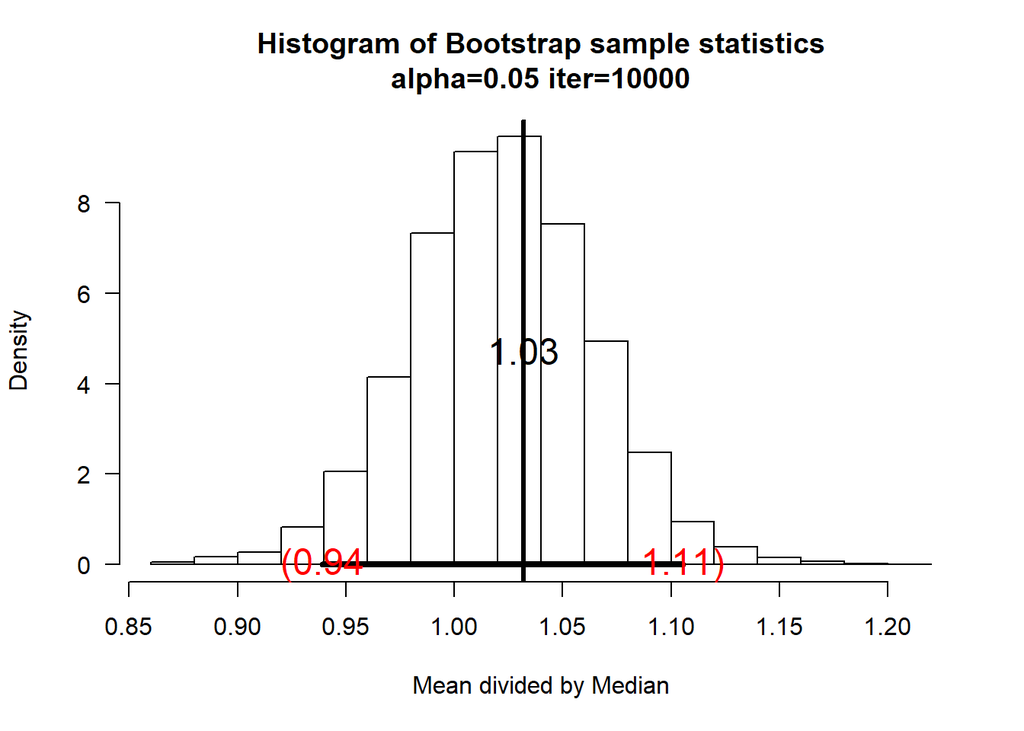

```r
set.seed(30)
sam2=rchisq(20,df=3)
sam2.mean=myboot2(x=sam2,alpha=a,fun="myf", xlab="Mean divided by Median")
```

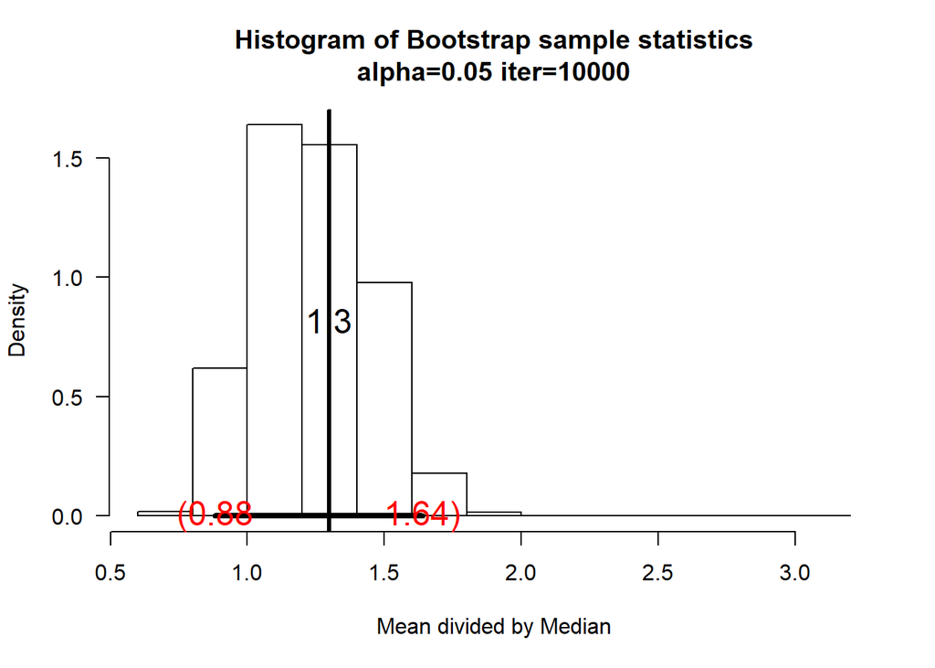

```r
set.seed(40)
sam3=rgamma(30,shape=2,scale=3)
sam3.mean=myboot2(x=sam3,alpha=a,fun="myf", xlab="Mean divided by Median")
```

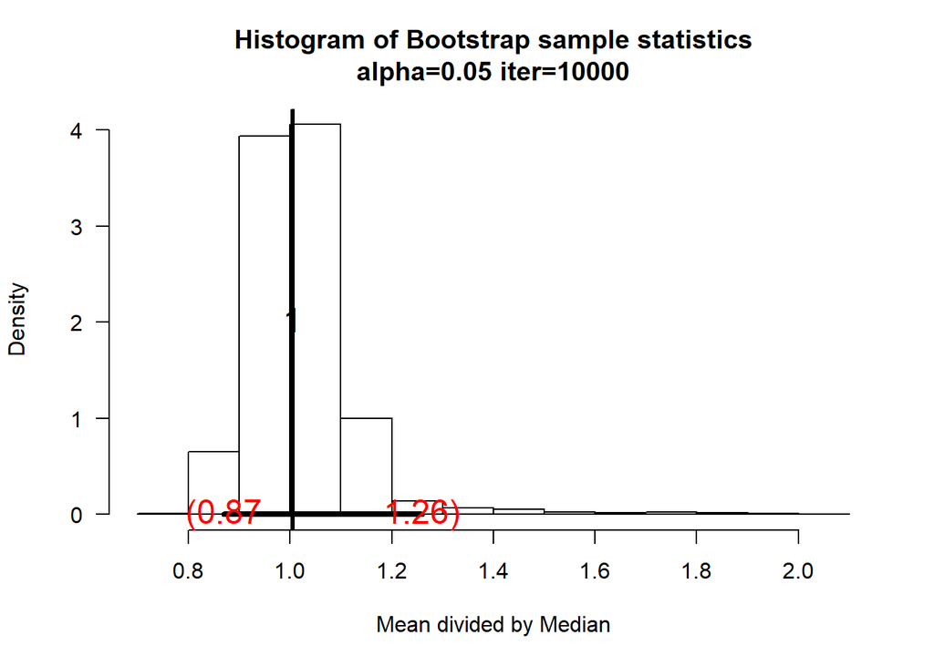

```r
set.seed(10)
sam4=rbeta(20,shape1=3,shape2=4)
sam4.mean=myboot2(x=sam4,alpha=a,fun="myf", xlab="Mean divided by Median")
```

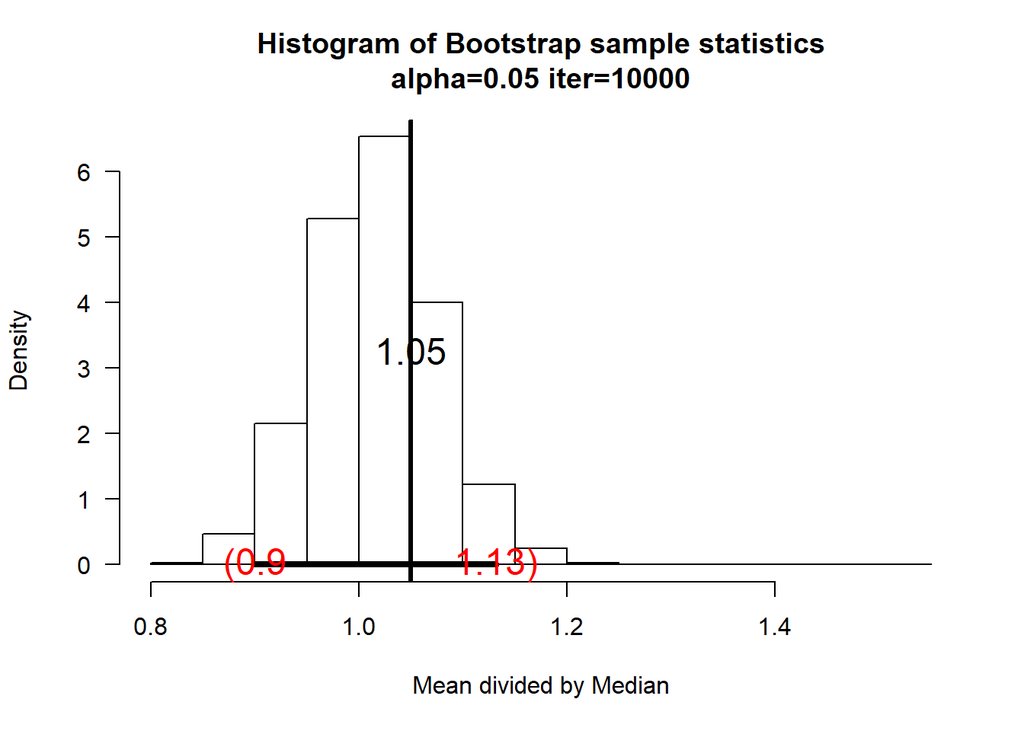

## Task 6

### 4 more myboot2() with alpha = 0.2 for mean and variance

```r
a=0.2
set.seed(39)
sam1=rweibull(25,1,2)
sam1.mean=myboot2(x=sam1,alpha=a,fun="mean",xlab="Mean")
```

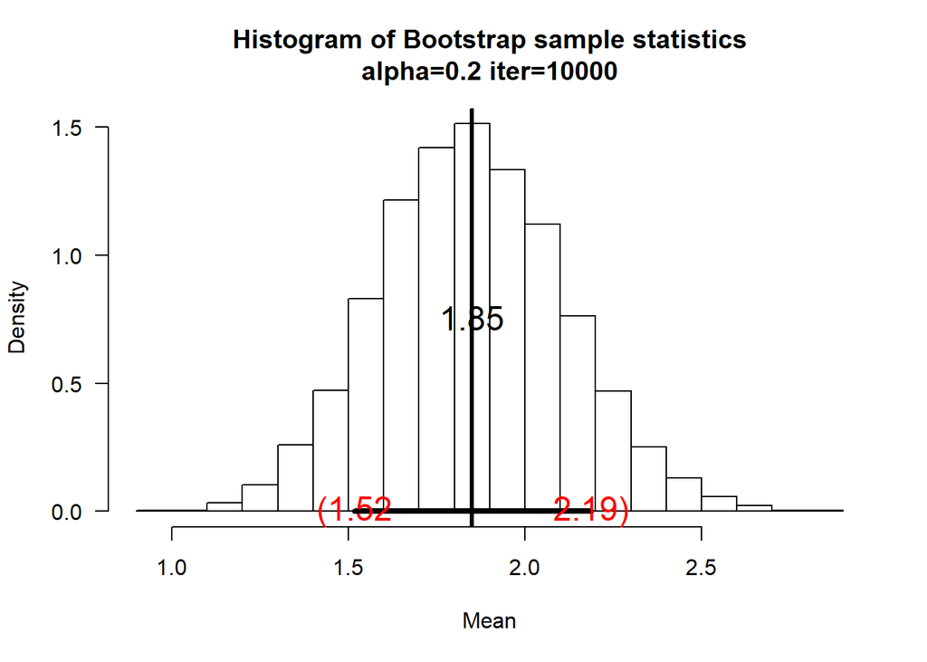

```r
sam1.var=myboot2(x=sam1,alpha=a,fun="var",xlab="Variance")
```

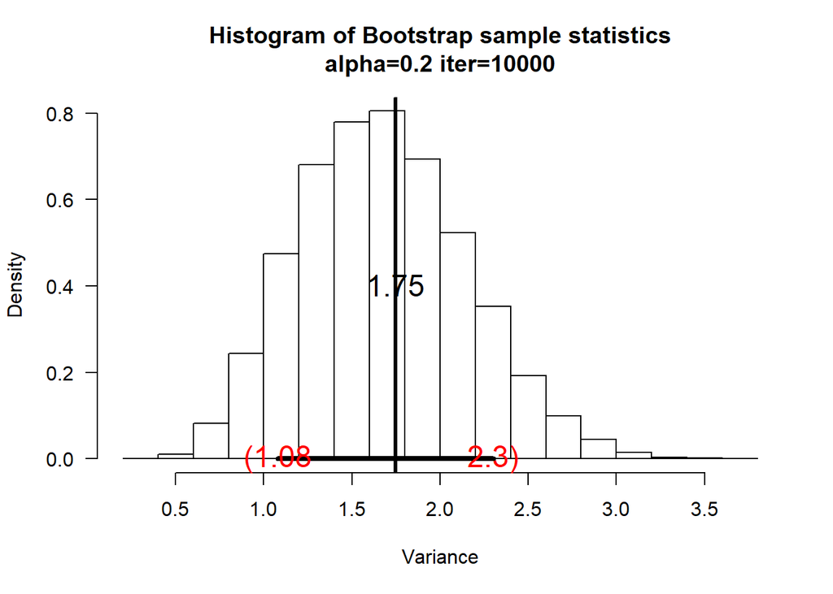

```r
set.seed(30)
sam2=rpois(20,3)
sam2.mean=myboot2(x=sam2,alpha=a,fun="mean",xlab="Mean")
```

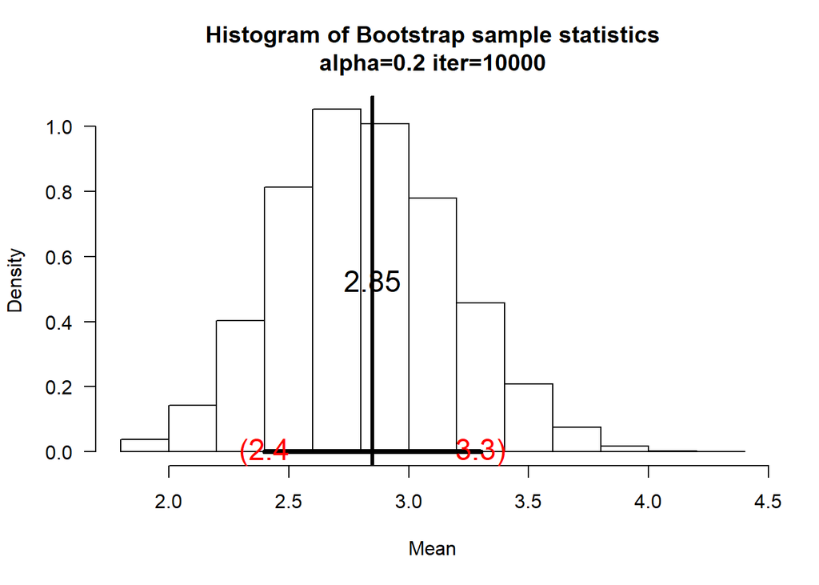

```r
sam2.var=myboot2(x=sam2,alpha=a,fun="var",xlab="Variance")
```

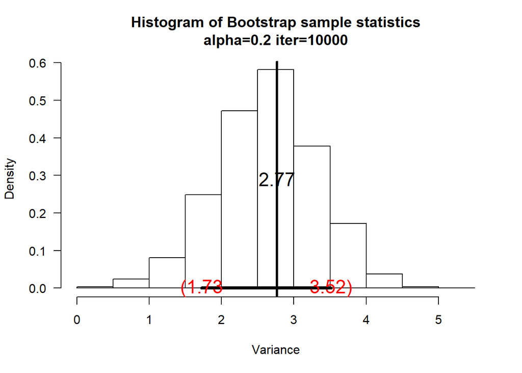

```r
set.seed(40)
sam3=rgeom(30,0.7)
sam3.mean=myboot2(x=sam3,alpha=a,fun="mean",xlab="Mean")
```

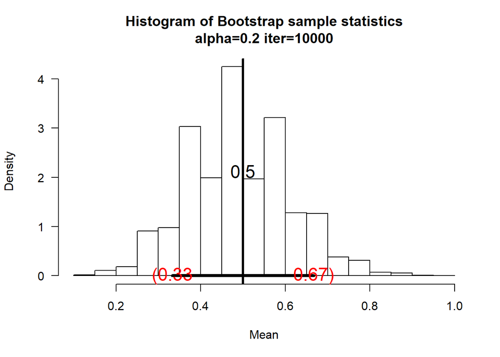

```r
sam3.var=myboot2(x=sam3,alpha=a,fun="var",xlab="Variance")
```

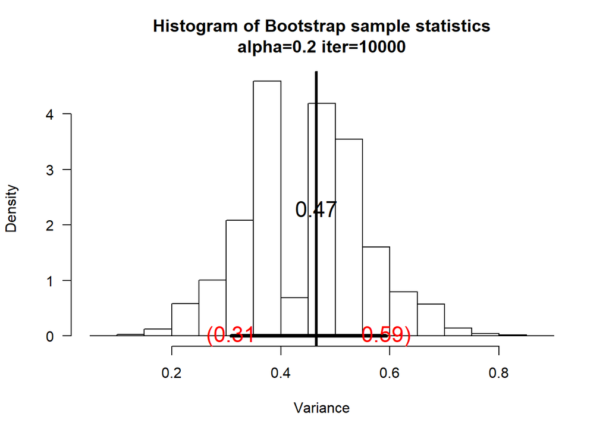

```r
set.seed(10)
sam4=rbinom(5,20,0.3)
sam4.mean=myboot2(x=sam4,alpha=a,fun="mean",xlab="Mean")
```

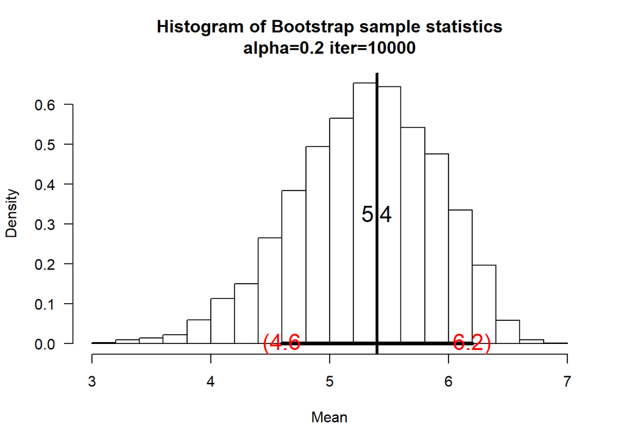

```r
sam4.var=myboot2(x=sam4,alpha=a,fun="var",xlab="Variance")
```

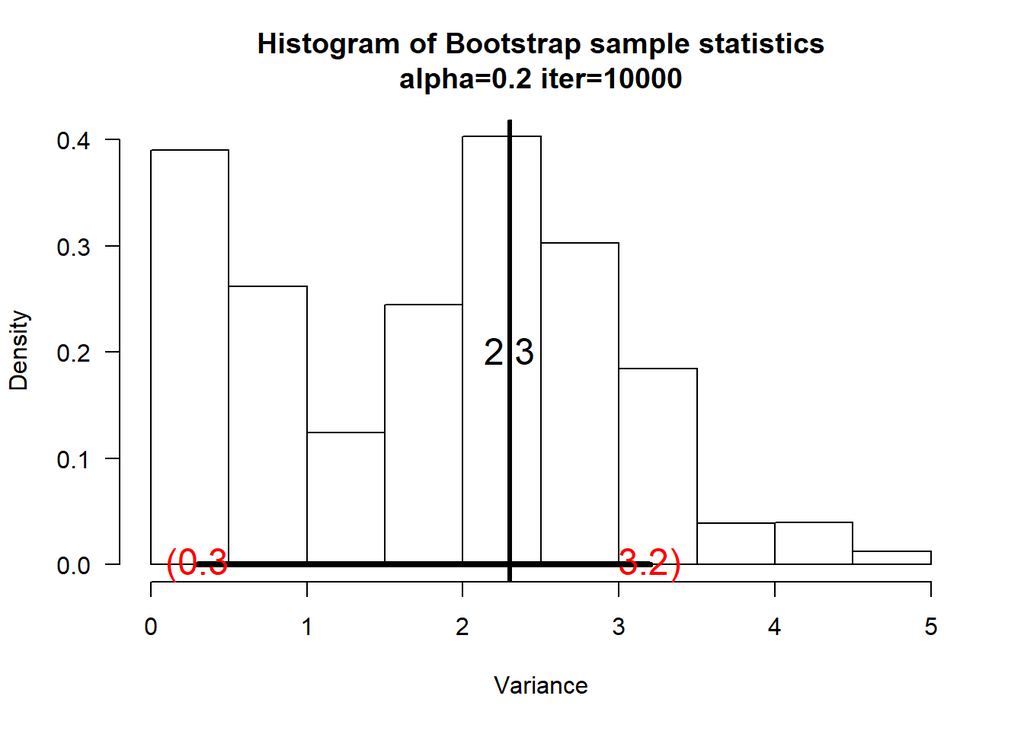

## Task 7

### 2 interesting invervals, using my boot

```r
set.seed(68)
a=0.05
mean = 10
sd = 4
n = 20
sam=rnorm(n,mean,sd)
#mean
sam.mean=myboot2(x=sam,alpha=a,fun="mean",xlab="Mean")
```

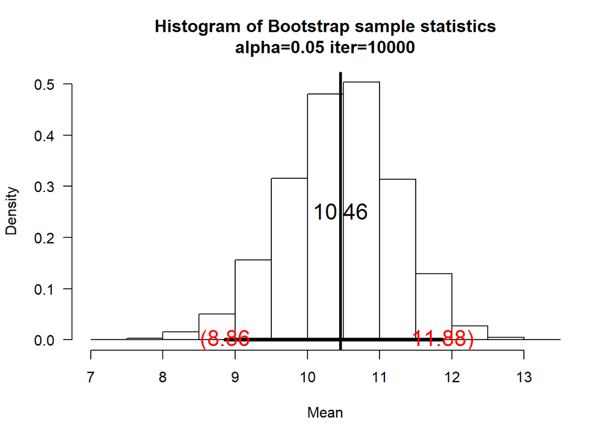

```r
#median
sam.var=myboot2(x=sam,alpha=a,fun="median",xlab="Median")
```

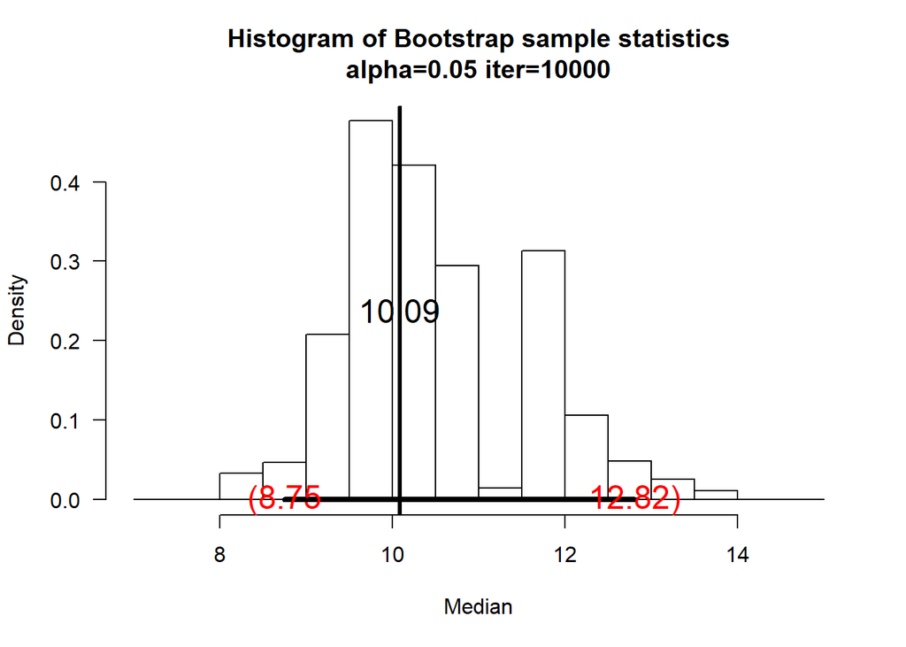

### Using theory

For the mean

```r
val=mean(sam)
z = qnorm((1-a)*0.95,mean=0,sd=1)
sdn=sd/sqrt(n)
val-z*sdn
```

```
## [1] 9.300197
```

```r
val+z*sdn
```

```
## [1] 11.61843
```

For the median

```r
val=median(sam)
z = qnorm((1-a)*0.95,mean=0,sd=1)
sdn=sd/sqrt(n)
val-z*sdn
```

```
## [1] 8.929217
```

```r
val+z*sdn
```

```
## [1] 11.24744
```

## Task 8

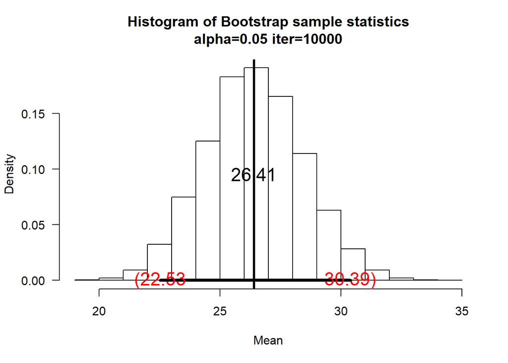

```r
FIREDAM=read.csv("FIREDAM.csv")
mypackage::myboot2(x=FIREDAM$DAMAGE,xlab="Mean",fun="mean")
```